# Overview of Pathways Data

## Sampling Strategy

- [Link](https://www.pathwaysstudy.pitt.edu/sampling.html)
- Maricopa County, AZ and Philadelphia, PA.
- At least 14 years old but under the age of 17 at the time the offense was committed.
- Only serious offenses (mostly felonies with some misdemeanor property, sexual assault, and weapons offenses).
- Provided informed assent or consent (parental consent for all those under the age of 18 at time of enrollment).
- Proportion of male youth found guilty of a drug charge was capped at 15% to avoid over-representation.
- All females as well as all youth being considered for trial in the adult system (who met age and crime criteria) were approached for enrollment.
- 20% of youth approached for participation declined.

## Data Collection

- [Link](https://www.pathwaysstudy.pitt.edu/datacollectionprocedures.html).
- Baseline Interview (First baseline interview completed in November 2000, last one completed in March 2003).
- Follow-up Interviews at 6, 12, 18, 24, 30, 36, 48, 60, 72, and 84 months past baseline (first follow up interview was May 2001 and last was March 2010). Basically every 6 months for the first 3 years and then annually thereafter. Participants were contacted every 3 to 6 months over the entire course of the study to provide updated contact information.
- Data were collected with computer-assisted interviews which took place in participants’ homes, libraries, other public places, or in facilities. Trained interviewers read each item aloud and respondents were allowed to enter their responses on a key pad (to maximize privacy).
- Self-report information is supplemented and validated through interviews with collateral reporters and using official record information (FBI arrest records and juvenile/adult court records from each jurisdiction).

### Baseline Interview

- [Link](https://www.pathwaysstudy.pitt.edu/baselineinterview.html).
- Conducted within 75 days of adjudication (juvenile system) or within 90 days of decertification hearing in Philadelphia or adult arraignment in Arizona.
- **Background characteristics** (e.g. demographics, offense history, academic achievement), **individual functioning** (e.g. work and school performance, substance abuse), **psychosocial development and attitudes** (e.g. impulse control, susceptibility to peer influence), **family context** (e.g. household composition), **personal relationships** (e.g. quality of romantic relationships and friends, peer delinquency, contacts with caring adults), **community context** (e.g. neighborhood conditions, personal capital, social ties).
- Conducted in two 2-hour sessions.
- [Link to word document with a comprehensive overview of each variable collected during the baseline interview](https://www.pathwaysstudy.pitt.edu/documents/baselineReferenceList.doc).

### Follow-up Interviews

- [Link](https://www.pathwaysstudy.pitt.edu/followupinterview.html).
- Took approximately 2 hours.
- Study participants were paid using a graduated payment schedule ranging from $50 to $115.
- A **window of opportunity** opened 6 weeks prior to the follow-up interview target date and closed 8 weeks after the target date. If the follow-up interview couldn’t be completed within this time frame, it was considered a missed interview.

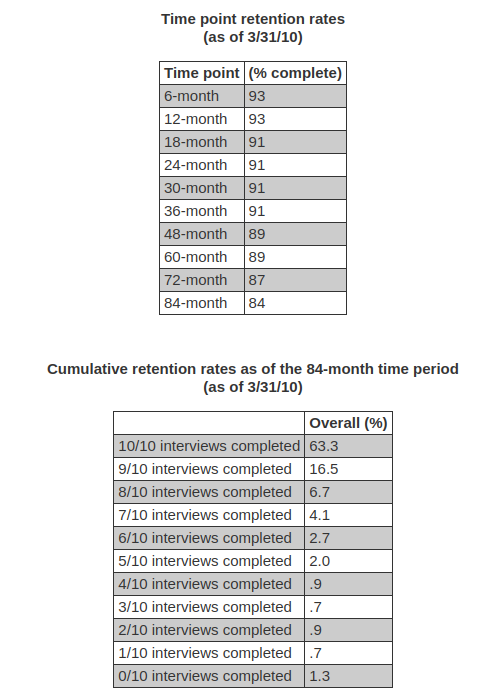